# ggplot2 (一)

Kemushi54

2018年6月29日

## 前言

這篇主要會著重在 ggplot2 的架構，以及實際操作時，程式語言撰寫的文法。在開始本篇之前，先推這一篇[淺談資料視覺化以及ggplot2實踐](https://leemengtaiwan.github.io/data-visualization-from-matplotlib-to-ggplot2.html)，裡面談了很多視覺化實踐的概念，關於 ggplot2 的架構也講得很詳細 (詳細到覺得推完這篇就可以結束惹XD“)，本篇部分的概念也都是從這篇來的。

談到資料視覺化 (非互動式的圖)，在 R 語言當中數一數二常用的 package，非 ggplot2 莫屬了！主要的原因在於它有很大的彈性，可以用簡單幾行的程式碼來瞭解資料的狀態，也可以透過調整多項參數來修改每一項在圖上所看到的項目，來輸出看起來很專業的圖。

ggplot2 程式碼的架構是圖層式的，主要分成 7 個層次，在撰寫 ggplot 的時候，會由下往上一層一層建立。7 層的架構看起來雖然很複雜，不過在實際出圖的時候，並不是每一層都需要去設定參數，最基本的架構只要給定最下面的三層，Data、Aesthetics 以及 Geometries 的設定，其他層採用預設值就可以出一張圖了。

- Data：資料層，也就是我們要拿來視覺化的資料。
- Aesthetics：視覺變數層，中文翻譯起來有點難懂，不過簡單來說就是告訴 ggplot 我們的 x 跟 y 分別對應到資料當中的哪個欄位，會用 `aes()` 來包住。
- Geometries：幾何圖形層，用不同的函數來指定我們的資料要以什麼樣的圖形呈現，像是要呈現點的話對應的函數是 `geom_point()`、長條圖對應到 `geom_bar()`、盒鬚圖對應到 `geom_boxplot()` 等。ggplot的各種幾何圖形層函數可以見 [ggplot2 Cheet sheet](https://www.rstudio.com/wp-content/uploads/2016/11/ggplot2-cheatsheet-2.1.pdf) 裡面的 geom_ 系列。

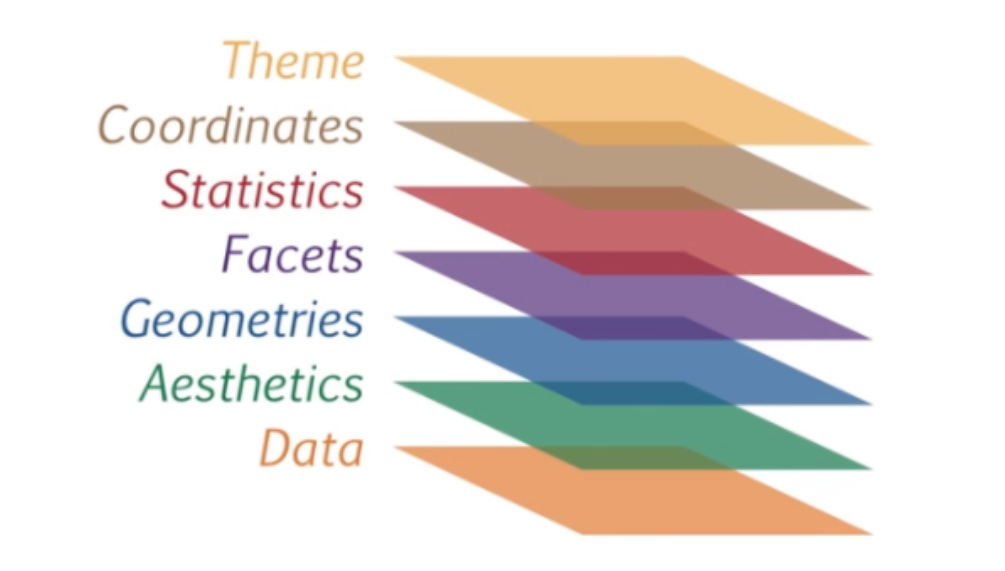

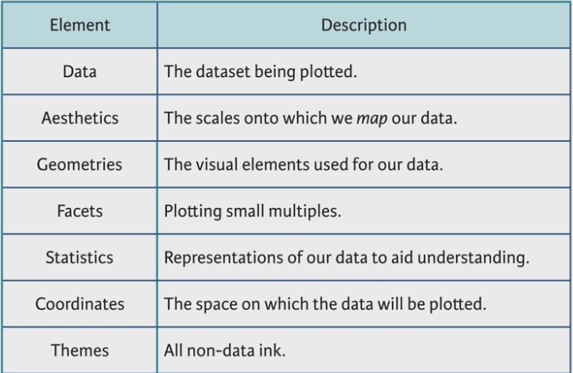

Image Credit: DataCamp - Data Visualization with ggplot2 (Part 1)

假設今天我們有一個資料表如下，包含物種名稱 (Species) 與隻數 (Count)

| Species | Count |  |
| --- | --- | --- |
| Kentish Plover | 1000 |  |
| Common Teal | 300 |  |
| Little Egret | 120 |  |

最簡單的指令只要像下面這樣，就可以輸出一張長條圖來呈現不同物種的隻數

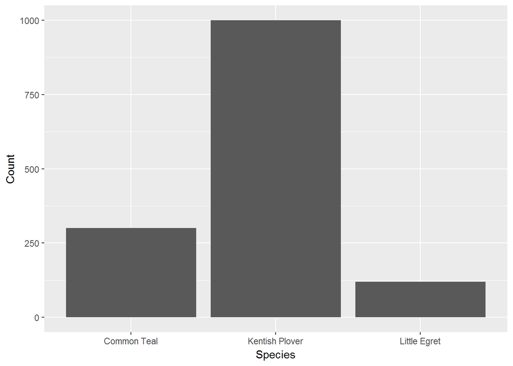

```r
ggplot() +
  geom_col(data = bird.data,
           aes(x = Species, y = Count))
```

在上方的程式碼中，`ggplot()` 用來開啟一張新的空白圖層、 `geom_col()` 是幾何圖形層，**col** 代表繪製的是長條圖，裡面的 `aes(x = Species, y = Count)` 則是視覺變數層，告訴 ggplot2 我們的 x 軸要看 Species 這個欄位，y 軸要看 Count 這個欄位。其中對於 **資料層** 以及 **視覺變數層** 的指定，可以包在 `geom_col()` 裡面，也可以放在 `ggplot()` 裡面，改寫成像下面這樣。

```r
ggplot(data = bird.data,
       aes(x = Species, y = Count)) +
  geom_col()
```

不過由於在實際應用時，很多時候視覺化的呈現需要結合多個資料表，這種時候資料層 (data) 以及視覺變數層 (aes()) 就要放在幾何圖形層 (geom_col()) 當中來指定，也就是第一種表示法才行。所以雖然對單一資料表的出圖來說，兩種表示法都可以，但我自己還是習慣用第一種方式來撰寫，一來讓程式碼的文法一致，二來也可以減少出錯的機會。

資料視覺化依目的可以簡單分為

- 探索資料
- 說故事

在探索資料的階段，主要是讓資料分析者自己了解資料的特性，有些時候可以直接拿原始資料來畫畫看資料的趨勢。不過當到了說故事的階段，要透過視覺化來詮釋資料的特徵給別人時，往往就會需要經過一番資料角力 (data wrangling) (其實就是資料整理，不過角力聽起來比較潮XD“”)，經過資料篩選、清理、型態轉換等流程，才能產出要繪圖的資料，再進一步用這個繪圖資料來出圖。所以對資料視覺化這件事來說，不單是繪圖用的 ggplot2，資料角力相關的套件如 dplyr、data.table 也需要了解熟悉。 以下範例也會包含簡單的資料角力，不過在細節上不會著墨太多，想了解細節的部分請參照 [data.table教學](https://kemushi54.github.io/R-basic/data_table.html)，或是期待(?)之後應該也會寫(但可能會拖搞拖很久(艸))的一些小型 project 實作分享。

## ggplot2 實作

### 環境設定

先安裝跟呼叫等一下會用到的套件

```r
# 安裝套件
list.of.packages <- c("data.table", "magrittr", "tidyr", "ggplot2")
new.packages <- list.of.packages[!(list.of.packages %in% installed.packages()[,"Package"])]
if(length(new.packages)) install.packages(new.packages)

# 呼叫套件
library(data.table)
library(magrittr)
library(tidyr)
library(ggplot2)
```

### 資料整理

這邊我們用第一篇 data.table 教學使用的 BBS 資料來作範例，資料取得的方法以及資料整理的細節請參考 [data.table教學](https://kemushi54.github.io/R-basic/data_table.html) 囉！

#### 讀取資料

```r
BBS <-
  fread("E:/R markdown/BBS2009-2015/occurrence.txt",
        sep = "\t", encoding = "UTF-8")
```

#### 資料篩選

```r
BBS.select <- BBS %>%
  # 擷取需要的欄位並且重新命名
  .[, list(Species = vernacularName,
           Count = individualCount,
           Recorder = recordedBy,
           eventID,
           Long = decimalLongitude,
           Lat = decimalLatitude
           )] %>%
  # 從eventID欄位中，用separate來分離出有用的資訊 (eventID: TWBBS_2015_A33-13_05_02)
  separate("eventID", c("Dataset", "Year", "Site", "Point", "Order"), sep = "_") %>%
  # 移除Dataset欄位
  .[, Dataset := NULL]
```

初步整理完的資料表長這樣

| Species | Count | Recorder | Year | Site | Point | Order | Long | Lat |
| --- | --- | --- | --- | --- | --- | --- | --- | --- |
| 麻雀 | 12 | 廖自強 | 2015 | A33-13 | 05 | 02 | 120.5573 | 23.92991 |
| 麻雀 | 8 | 廖自強 | 2015 | A33-13 | 06 | 02 | 120.5594 | 23.92730 |
| 白頭翁 | 2 | 廖自強 | 2015 | A33-13 | 03 | 02 | 120.5574 | 23.92519 |
| 珠頸斑鳩 | 1 | 廖自強 | 2015 | A33-13 | 04 | 02 | 120.5556 | 23.92750 |
| 灰頭鷦鶯 | 1 | 廖自強 | 2015 | A33-13 | 06 | 02 | 120.5594 | 23.92730 |

### 範例一

#### 從 2009-2015 年樣區數量的成長趨勢 (長條圖)

要畫樣區數隨著時間成長的趨勢圖，首先就要計算每年的樣區個數

```r
data.01 <-
  BBS.select[, .(nSite = uniqueN(Site)),  # uniqueN計算Site的項目個數
             by = Year]
```

| Year | nSite |
| --- | --- |
| 2015 | 354 |
| 2009 | 148 |
| 2010 | 140 |
| 2011 | 253 |
| 2012 | 311 |
| 2013 | 291 |
| 2014 | 293 |

接著我們就用 **data.01** 來繪圖

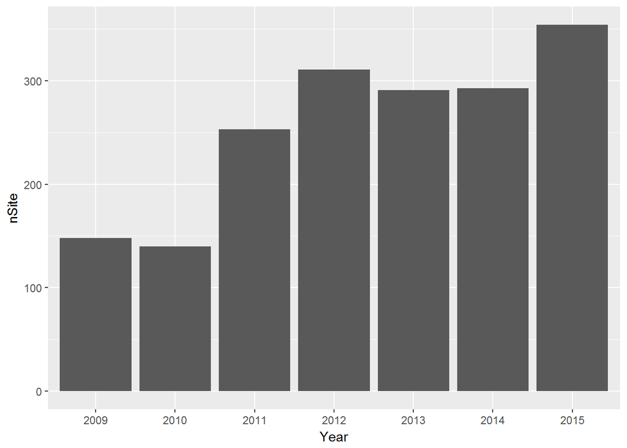

```r
ggplot() +
  geom_col(data = data.01,
           aes(x = Year, y = nSite))
```

在 BBS 的樣區中有分低中高三個海拔段，在樣區編號中第一個英文字母代表的就是樣區所屬的海拔段，所以也可以來看不同海拔段的樣區數，他們的成長趨勢分別為何。 在畫圖之前我們要先產生繪圖需要的資料，也就是不同海拔段每年的調查樣區數。

```r
data.02 <-
  # 利用substr取Site這個欄位的第一個字元，作為elevation的值
  BBS.select[, elevation := substr(Site, 1, 1)] %>%
  # 利用uniqueN計算每個海拔段每年樣區的項目個數
  .[, .(nSite = uniqueN(Site)),
    by = list(elevation, Year)]
```

| elevation | Year | nSite |
| --- | --- | --- |
| A | 2015 | 306 |
| B | 2015 | 34 |
| C | 2015 | 14 |
| A | 2009 | 108 |
| B | 2009 | 30 |

利用新的 **data.02** 來製圖，這邊除了要呈現每年的數量外，還要區分不同的海拔段，所以在 `aes()` 中多了 group 來指定資料分組的方式，以及透過 `fill = elevation` 來指定不同海拔段的資料在圖中以填入不同的顏色的方式來區分。

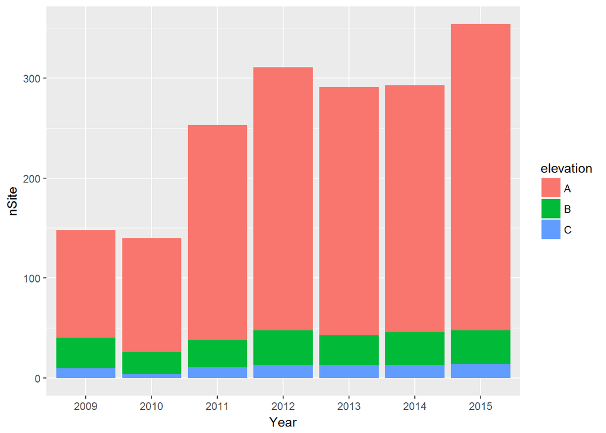

```r
ggplot() +
  geom_col(data = data.02,
           aes(x = Year, y = nSite,
               group = elevation, fill = elevation))
```

另外可以透過 `position = "dodge"` 來讓不同海拔段的樣區數長條圖以併排的方式來呈現。

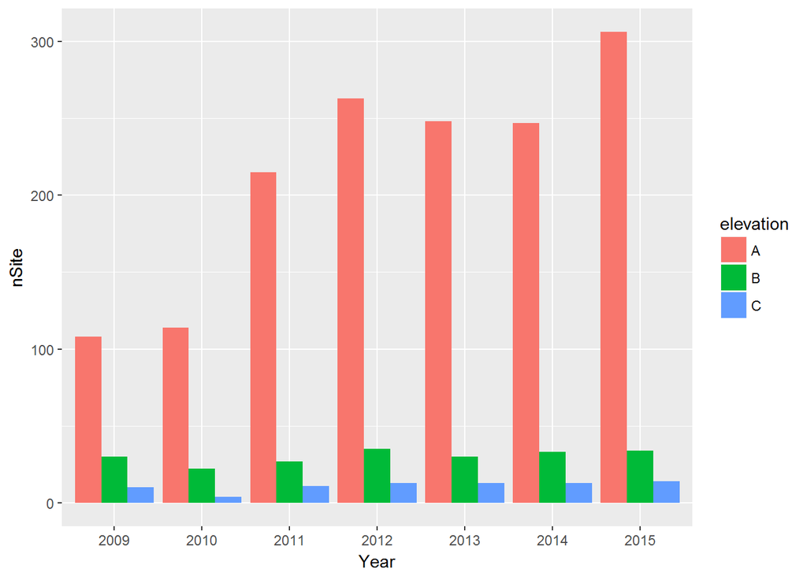

```r
ggplot() +
  geom_col(data = data.02,
           aes(x = Year, y = nSite,
               group = elevation, fill = elevation),
           position = "dodge")
```

也可以透過更多參數的設定來修改既有的圖示還有坐標軸的資訊。  
坐標軸、圖片標題等參數的設置方式有很多種，選擇自己寫的最順手的方式就好~

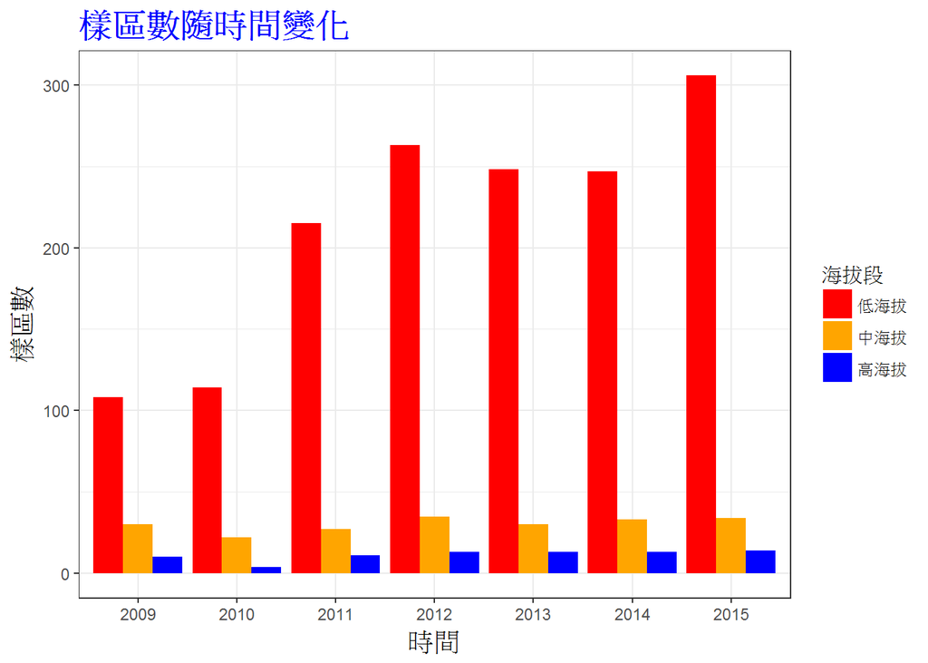

```r
ggplot() +
  geom_col(data = data.02,
           aes(x = Year, y = nSite,
               group = elevation, fill = elevation),
           position = "dodge") +
  scale_fill_manual(name = "海拔段", # 新的圖示名稱
                    breaks=c("A", "B", "C"), # 原始分類值
                    labels=c("低海拔", "中海拔", "高海拔"), # 新的分類值
                    values = c("red", "orange", "blue")) + # 指定新顏色
  labs(x = "時間", y = "樣區數", title = "樣區數隨時間變化") + # 指定x, y軸以及標題內容
  theme_bw() + # 設置版面樣式
  theme(plot.title = element_text(size=18, face="bold", color = "blue"), # 指定標題文字大小、樣式
        axis.title = element_text(size=14)) # 指定坐標軸文字大小、樣式
```

注意這邊我設定圖示相關參數的函數是 `scale_fill_manual()`，是呼應 `aes()` 內的 `fill = elevation`設定。如果今天是要讓不同分組的資料以不同形狀 (shape) 來區分，對應的函數會是 `scale_shape_manual()`，要用不同線條顏色 (color) 來區分則是 `scale_color_manual()`。  
在各項參數設置時要注意前後順序，如同一開始所說的，ggplot2 的架構是圖層式的，不管是繪製的圖層或是參數的設置，前面的設定都會被後面的設定覆蓋掉，像是上面程式碼最後的 `theme()` 跟 `theme_bw()` 的前後順序如果反過來，輸出的圖會是不一樣的，有興趣的話可以試試把他們反過來的效果~

除了讓海拔段的資訊以長條圖併排的方式呈現外，我們也可以依海拔段分成多張小圖來看，這個時候就會用到 facet 這一層的設置。 facet 有兩大家族：`facet_wrap()` 以及 `facet_grid()`，兩個的用途差不多，這邊就先示範 `facet_wrap()`。

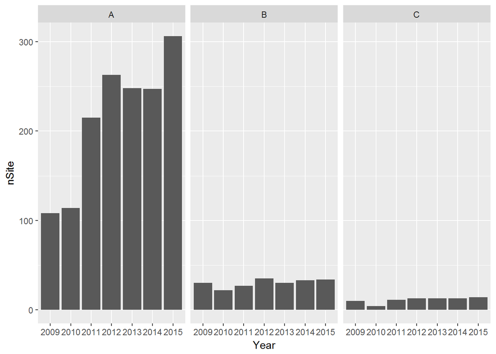

```r
ggplot() +
  geom_col(data = data.02,
           aes(x = Year, y = nSite)) +
  facet_wrap(~ elevation) # 指定依照elevation來分別作圖
```

也可以進一步在 facet_wrap 中加入更多參數來調整輸出的圖片

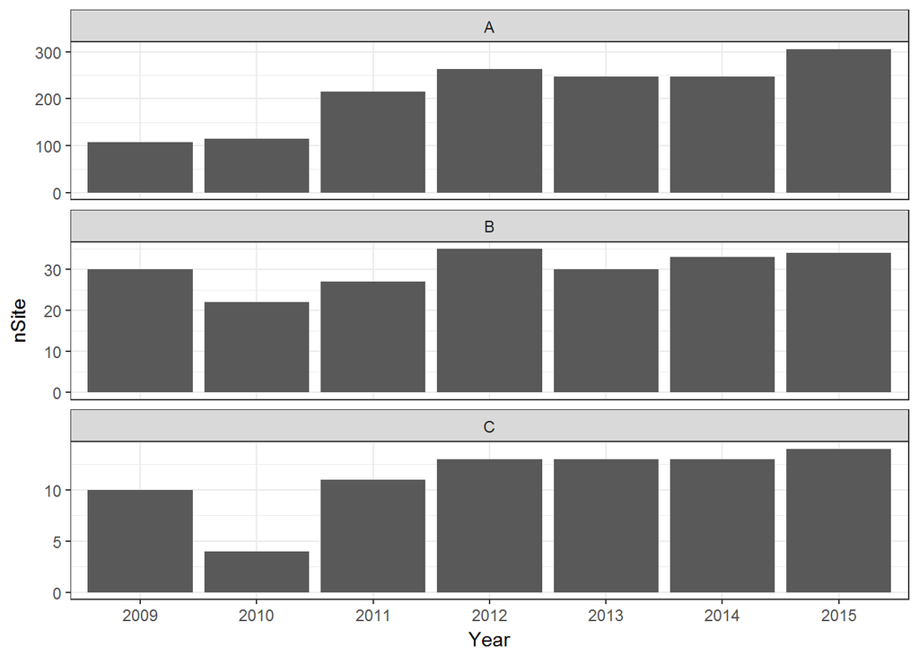

```r
ggplot() +
  geom_col(data = data.02,
           aes(x = Year, y = nSite)) +
  facet_wrap(~ elevation,
             ncol = 1, # ncol指定輸出的圖只排成一欄
             scale = "free_y") + # scale讓三張分圖y軸的範圍可以隨資料調整
  theme_bw()
```

### 範例二

#### 用 ggplot2 製作樣區地圖

利用BBS資料當中的樣區經緯度坐標，來呈現樣區在空間上的分布。 由於資料數量比較多，我們就先單看每年每個樣區的第一個樣點，在第一旅次調查時回傳的坐標位置

#### 資料準備

```r
# 準備樣點資料
data.03 <-
  BBS.select[Point == "01" & Order == "01"]

# 準備台灣地圖資料
library(rgdal)
TW.data <-
  # 讀取台灣縣市界的shapefile
  readOGR("E:/R markdown/COUNTY", "TW_COUNTY") %>%
  # 透過fortify()將shapefile的空間資訊轉成ggplot2可讀的data.frame
  fortify(TW, region = "COUNTYNAME") # 透過region來綁定原本shapfile屬性表的欄位
```

fortify 會擷取原本 shapefile 圖層中每個 polygon 的坐標點位，假設原本的 polygon 是由 6 個點位所組成，經過 `fortify()` 轉換後的資料，就會是 6 列的坐標值，並且在 group 欄位中，會擁有相同的值。像下圖的資料表中 group 同為 **宜蘭縣.1** 的這些資料就是代表組成同一個 polygon 的點位坐標。

| long | lat | order | hole | piece | id | group |
| --- | --- | --- | --- | --- | --- | --- |
| 121.9606 | 24.98822 | 1 | FALSE | 1 | 宜蘭縣 | 宜蘭縣.1 |
| 121.9607 | 24.98822 | 2 | FALSE | 1 | 宜蘭縣 | 宜蘭縣.1 |
| 121.9608 | 24.98824 | 3 | FALSE | 1 | 宜蘭縣 | 宜蘭縣.1 |
| 121.9609 | 24.98827 | 4 | FALSE | 1 | 宜蘭縣 | 宜蘭縣.1 |
| 121.9610 | 24.98830 | 5 | FALSE | 1 | 宜蘭縣 | 宜蘭縣.1 |
| 121.9611 | 24.98830 | 6 | FALSE | 1 | 宜蘭縣 | 宜蘭縣.1 |
| 121.9611 | 24.98826 | 7 | FALSE | 1 | 宜蘭縣 | 宜蘭縣.1 |
| 121.9613 | 24.98818 | 8 | FALSE | 1 | 宜蘭縣 | 宜蘭縣.1 |
| 121.9613 | 24.98818 | 9 | FALSE | 1 | 宜蘭縣 | 宜蘭縣.1 |
| 121.9615 | 24.98805 | 10 | FALSE | 1 | 宜蘭縣 | 宜蘭縣.1 |

#### 地圖繪製

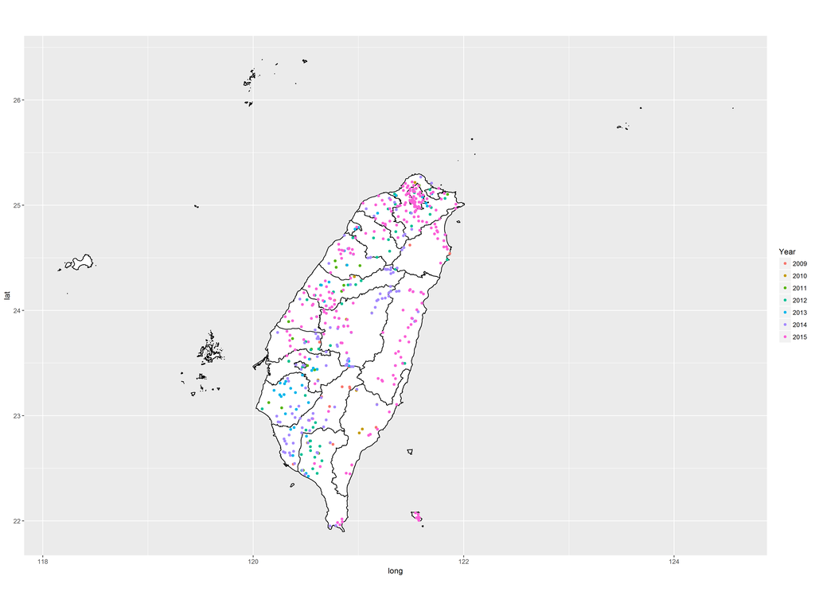

```r
ggplot() +
  # 台灣底圖 (底圖在下層，所以要寫在前)
  geom_polygon(data = TW.data,
               aes(x = long, y = lat, group = group), # group一定要設，不然ggplot會不知道那些點要連成一個polygon
               color = "black", fill = "white") + # 用color設定邊線顏色，fill設定區塊填滿的顏色，放在aes()之外
  # 樣點點位 (樣點點位在上層，所以要寫在後)
  geom_point(data = data.03,
             aes(x = Long, y = Lat, color = Year)) + # color讓不同年份的樣點以不同顏色來呈現
  coord_fixed() # 固定坐標的長寬比例，沒有設的話地圖很容易會變形
```

另外也可以透過前面提到的 facet_wrap() 來分年份產生樣點地圖

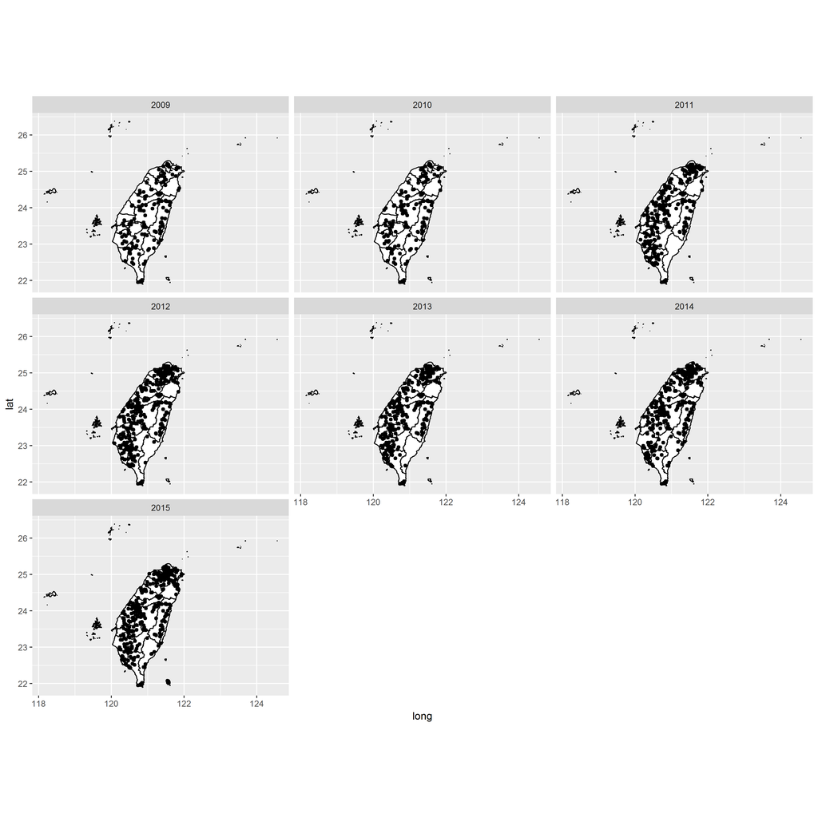

```r
p <- ggplot() +
  geom_polygon(data = TW.data,
               aes(x = long, y = lat, group = group),
               color = "black", fill = "white") +
  geom_point(data = data.03,
             aes(x = Long, y = Lat)) +
  coord_fixed() +
  facet_wrap(~ Year) # 利用facet_wrap來產生分年的地圖

p  # 畫出來看一下
```

#### 最後介紹圖片的輸出，ggsave()

```r
ggsave("圖片檔案.png",  # 檔案名稱
       plot = p,  # 圖片變數，如果沒有指定預設會儲存最後一張畫出來的圖
       path = "E:/for R markdown", # 檔案路徑，不包含檔名
       width = 12, # 圖片寬度
       height = 12, # 圖片長度
       dpi = 300) # dpi
```

這邊要注意的是，如果原本ggplot中沒有特別設定文字的大小，輸出圖檔文字、圖形的比例會受 ggsave 中圖片檔長寬設定所影響，長度跟寬度值設置的越大，圖片中文字跟圖形的比例就會變得比較小。